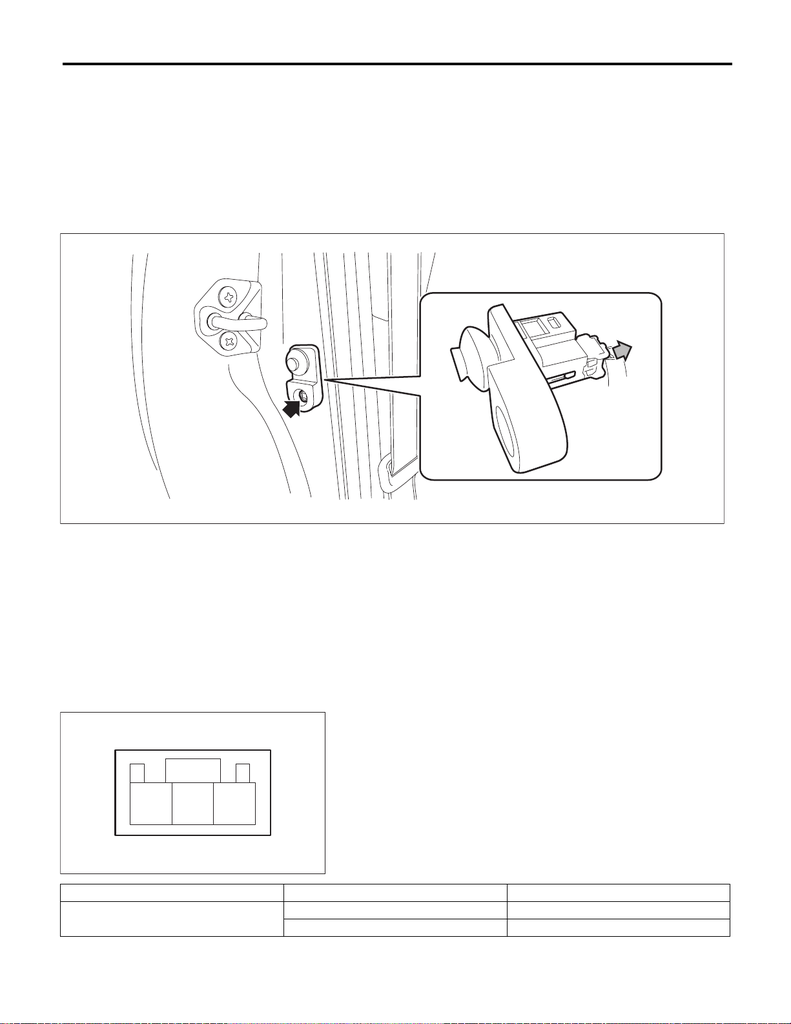

LI-78

Door Switch

LIGHTING SYSTEM

41.Door Switch

A: REMOVAL

1) Disconnect the ground cable from battery. <Ref. to NT-5, BATTERY, NOTE, Note.>

NOTE:

For models other than STI model, disconnect the ground terminal from battery sensor.

2) Remove the switch assembly - door.

B: INSTALLATION

1) Install the switch assembly - door.

2) Connect the battery ground terminal. <Ref. to NT-5, BATTERY, NOTE, Note.>

NOTE:

For models other than STI model, connect the ground terminal to battery sensor.

C: INSPECTION

1) Measure the resistance between connector terminals.

Preparation tool:

Circuit tester

2) Replace the switch assembly - door if the inspection result is not within the standard value.

LI-01057

LI-01748

3 1

2

Terminal No. Inspection conditions Standard

1 — 3

When the switch is not pressed Less than 1 Ω

When the switch is pressed 1 MΩ or more

[figure not shown]

AUTO HEADLIGHT BEAM LEVELER SYS-

TEM (DIAGNOSTICS)

AL(diag)

Page

1. Basic Diagnostic Procedure .......................................................................2

2. Check List for Interview ..............................................................................3

3. General Description ...................................................................................4

4. Electrical Component Location ..................................................................5

5. Control Module I/O Signal ..........................................................................6

6. Subaru Select Monitor ................................................................................7

7. Read Diagnostic Trouble Code (DTC) .....................................................10

8. Clear Memory Mode .................................................................................11

9. Inspection Mode .......................................................................................12

10. Read Current Data ...................................................................................13

11. List of Diagnostic Trouble Code (DTC) ....................................................14

12. Diagnostic Procedure with Diagnostic Trouble Code (DTC) ....................15

13. Diagnostics with Phenomenon .................................................................23